# Brook Trout Hg

Ethan Rutledge

12/13/2021

### Summary

Juvenile brook trout were raised at varying temperatures for 24 days in a lab. At the end of the 24 days a series of physiological and physical measurements we’re taken from each fish. My goal was to go back and analyze these fish for mercury (Hg) accumulation as a response to some of these physiological measurements to try and determine if any had predictive values. My main hypothesis however, was that higher growth rates will result in lower concentrations of Hg in brook trout. This phenomenon is known as somatic growth dilution.

### Definitions:

Hg - mercury

temp - temperature

growth - growth rate (g/day)

cort - plasma cortisol (ng/ml)

hsp - hepatosomatic Index

atp - gill Na+/K+-ATPase

hct - hematocrit

end_weight - weight at end of 24 day trial

```r
require(here)
require(psych)
```

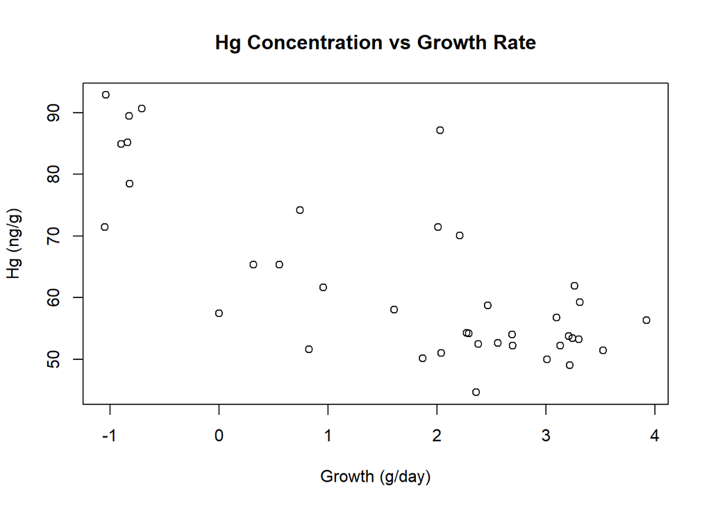

```r
bkt = read.csv(here("data", "Brook_Trout_Hg.csv"))

plot(Hg ~ growth, data = bkt, main = "Hg Concentration vs Growth Rate", ylab = "Hg (ng/g)", xlab = "Growth (g/day)")
```

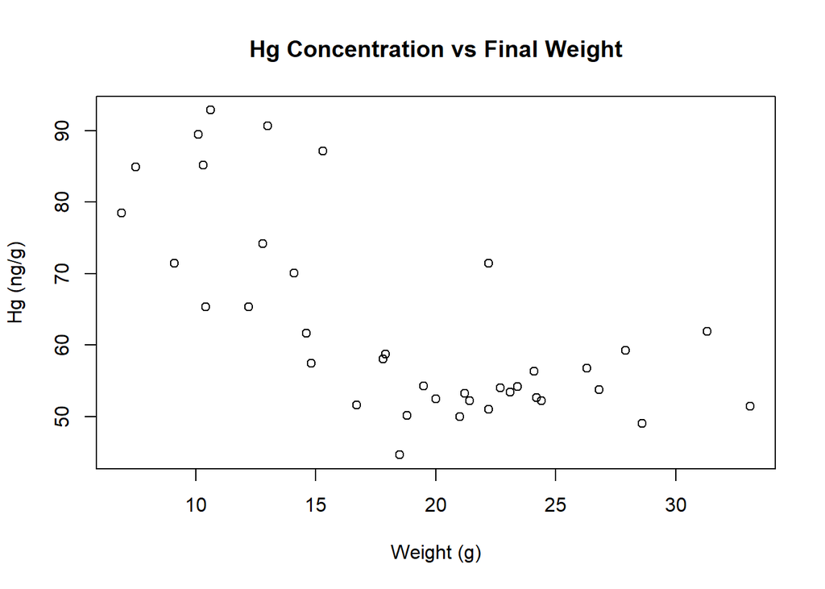

```r
plot(Hg ~ end_weight, data = bkt, main = "Hg Concentration vs Final Weight", ylab = "Hg (ng/g)", xlab = "Weight (g)")
```

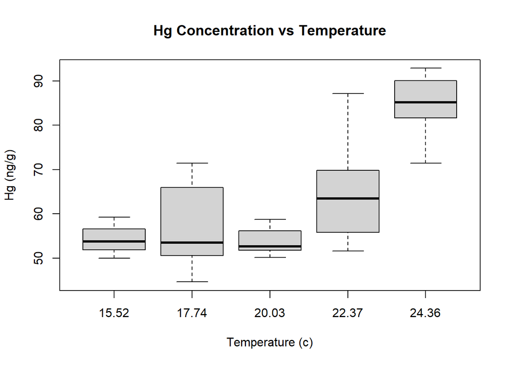

```r
boxplot(Hg ~ temp, data = bkt, main = "Hg Concentration vs Temperature", ylab = "Hg (ng/g)", xlab = "Temperature (c)")
```

```r
fit_temp = lm(Hg ~ temp, data=bkt)
    anova(fit_temp)
```

|  | Df | Sum Sq | Mean Sq | F value | Pr(>F) |
| --- | --- | --- | --- | --- | --- |
| temp | 1 | 3273.831 | 3273.831 | 32.66841 | 1.667543e-06 |
| Residuals | 36 | 3607.703 | 100.214 | NA | NA |

```r
fit_growth = lm(Hg ~ growth, data=bkt)
    anova(fit_growth)
```

|  | Df | Sum Sq | Mean Sq | F value | Pr(>F) |
| --- | --- | --- | --- | --- | --- |
| growth | 1 | 3906.155 | 3906.15477 | 47.26172 | 4.795581e-08 |
| Residuals | 36 | 2975.380 | 82.64944 | NA | NA |

```r
fit_both = lm(formula = Hg ~ growth * temp, data = bkt)
    anova(fit_both)
```

|  | Df | Sum Sq | Mean Sq | F value | Pr(>F) |
| --- | --- | --- | --- | --- | --- |
| growth | 1 | 3906.154765 | 3906.154765 | 52.92260178 | 2.009970e-08 |
| temp | 1 | 2.077472 | 2.077472 | 0.02814667 | 8.677584e-01 |
| growth:temp | 1 | 463.802329 | 463.802329 | 6.28383345 | 1.712922e-02 |
| Residuals | 34 | 2509.499865 | 73.808820 | NA | NA |

```r
fit_cort = lm(formula = Hg ~ cort, data = bkt)
    anova(fit_cort)
```

|  | Df | Sum Sq | Mean Sq | F value | Pr(>F) |
| --- | --- | --- | --- | --- | --- |
| cort | 1 | 1460.184 | 1460.1843 | 12.19907 | 0.001382633 |
| Residuals | 33 | 3949.979 | 119.6963 | NA | NA |

```r
fit_hsp = lm(formula = Hg ~ hsp, data = bkt)
    anova(fit_hsp)
```

|  | Df | Sum Sq | Mean Sq | F value | Pr(>F) |
| --- | --- | --- | --- | --- | --- |
| hsp | 1 | 4314.555 | 4314.55486 | 60.50846 | 3.212557e-09 |
| Residuals | 36 | 2566.980 | 71.30499 | NA | NA |

```r
fit_atp = lm(formula = Hg ~ atp, data = bkt)
    anova(fit_atp)
```

|  | Df | Sum Sq | Mean Sq | F value | Pr(>F) |
| --- | --- | --- | --- | --- | --- |
| atp | 1 | 1852.702 | 1852.7020 | 13.26297 | 0.0008449013 |
| Residuals | 36 | 5028.832 | 139.6898 | NA | NA |

```r
fit_hct = lm(formula = Hg ~ hct, data = bkt)
    anova(fit_hct)
```

|  | Df | Sum Sq | Mean Sq | F value | Pr(>F) |
| --- | --- | --- | --- | --- | --- |
| hct | 1 | 4440.843 | 4440.84280 | 65.50206 | 1.278498e-09 |
| Residuals | 36 | 2440.692 | 67.79699 | NA | NA |

```r
fit_weight = lm(formula = Hg ~ end_weight, data = bkt)
    anova(fit_weight)
```

|  | Df | Sum Sq | Mean Sq | F value | Pr(>F) |
| --- | --- | --- | --- | --- | --- |
| end_weight | 1 | 3258.128 | 3258.1278 | 32.37081 | 1.807057e-06 |
| Residuals | 36 | 3623.407 | 100.6502 | NA | NA |

```r
AIC(fit_temp, fit_growth, fit_both, fit_cort, fit_hsp, fit_atp, fit_hct, fit_weight)
```

|  | df | AIC |
| --- | --- | --- |
| fit_temp | 3 | 286.8625 |
| fit_growth | 3 | 279.5399 |
| fit_both | 5 | 277.0689 |
| fit_cort | 3 | 270.7398 |
| fit_hsp | 3 | 273.9295 |
| fit_atp | 3 | 299.4829 |
| fit_hct | 3 | 272.0125 |
| fit_weight | 3 | 287.0275 |

```r
AIC(fit_both, fit_growth, fit_temp)
```

|  | df | AIC |
| --- | --- | --- |
| fit_both | 5 | 277.0689 |
| fit_growth | 3 | 279.5399 |
| fit_temp | 3 | 286.8625 |

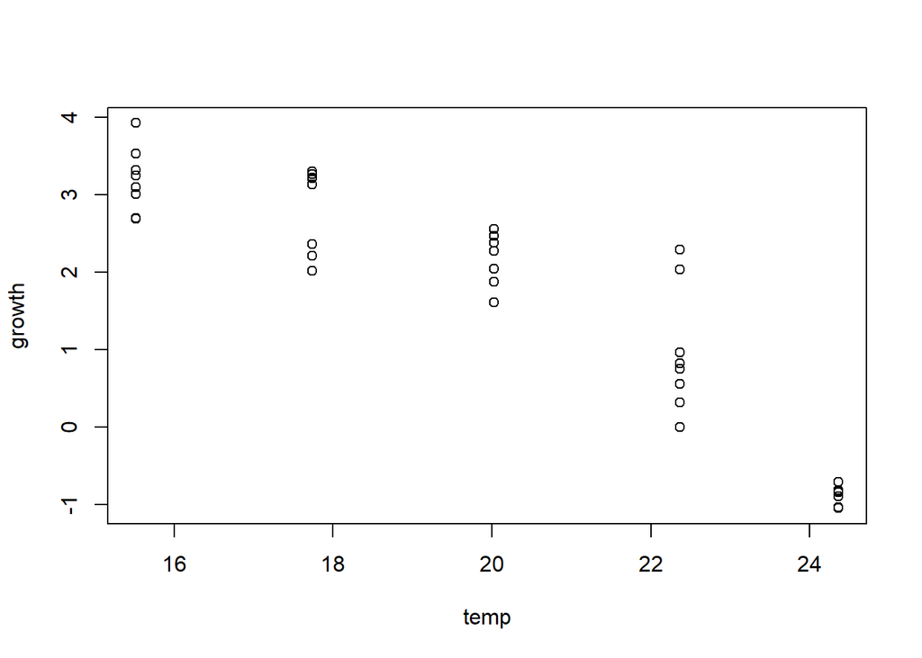

```r
plot(growth ~ temp, data = bkt)
```

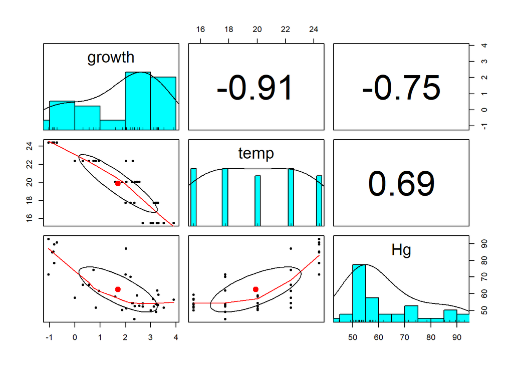

```r
pairs.panels(bkt[,c("growth", "temp", "Hg")])
```

### Conclusions

Based on the ANOVA tables, each of the variables measured are strong predictors of mercury accumulation. I suspect that either temperature or growth are working in the background driving those measurements to be significant.

In the mean time I ran an interactive model with temperature and growth (the two way ANOVA), in the output table growth is still a significant predictor of Hg, temperature is no longer a significant predictor and the interaction between the two is also significant. To me this means that growth and temp are correlated, but growth rather than temperature is driving the bus.

I also ran AIC on all of the linear models. Cortisol, HCT and HSP had the best scores. The three models that followed were; growth~temp, growth, and temperature. I’m a little unsure on how to interpret these results. I ran AIC on growth~temp, growth, and temp and the lowest AIC was growth~temp.